# Presentation Data Analytics

26/11/2020

## Context

- This project aims to analyze AirBnb’s data for three different cities: Amsterdam, Barcelona and Bordeaux.
- For this purpose, we created a Shiny app in R

## Shiny app architecture

- First part allows the users to make a cross-analysis among the three cities to compare several of the data’s features
- Second part allows the users to look more specifically into one of these cities once he has chosen a city

## Part 1: Cross-Analysis features selection

Allows the users to select between 3 different features :

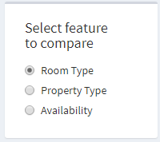

## Part 1: Cross-Analysis cities selection

Allows the users to select 2 cities to compare.

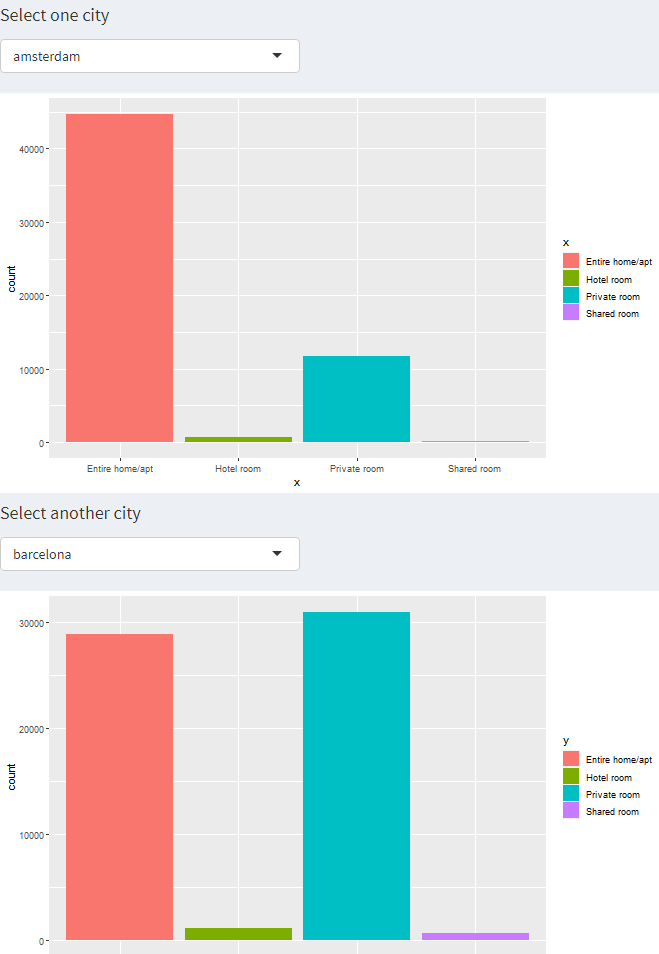

## Part 2: Deep dive analysis date selection

- Analysis is done on **3 cities** located in **3 different countries** and **3 different dates**
- You can also see the sidebar menu of the app, including a **specific display for each city** and a global data comparator

[figure not shown]

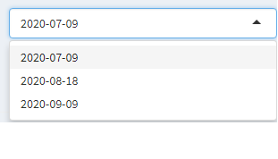

## Part 2: Map overview

[figure not shown]

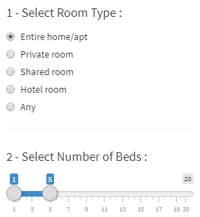

- **The map displaying residences** responding to the defined criterias
- The different parameters that influences the map display

## Part 2: Availability check

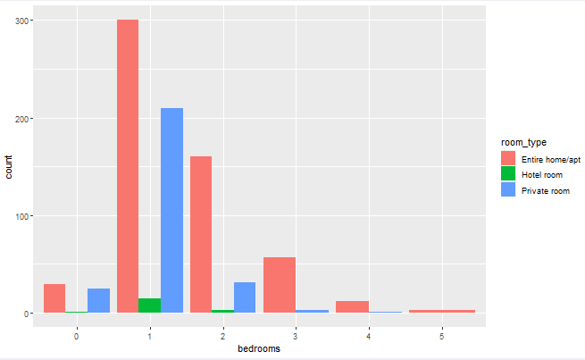

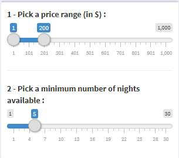

## Conclusion

- Thank you for your attention !